# Part 1: Data Viz Review

RLEL

# Visualizing tidy data w/ `ggplot`

## Reviewing the basics of the Grammar of Graphics

**Three main components:**

- data `ggplot()`
  - Tells ggplot which data object to use
  - data.frame
  - tibble
- aesthetics `aes()` `aes =`
  - Tells ggplot to know how to treat your data.
  - x
  - y
  - can relate to parts of your data
    - color (for lines, points, borders)
    - fill (for geometries that have borders and the inside can be another color)
    - size (AKA ‘cex’ in base R)
    - shape (AKA ‘pch’ in base R)
    - lty (linetype)
  - style (not typically linked to data)
    - lwd (line width)
    - alpha (transparency)
  - extras (e.g. positioning text labels)
    - vjust (relative vertical position from 0 to 1)
    - hjust (relative horizontal position from 0 to 1)
- geometry `geom_...`
  - geom_point
  - geom_line
  - geom_bar
  - geom_boxplot
  - geom_violin
  - geom_histogram
  - geom_density
  - geom_area
  - geom_smooth
  - extras for labeling
    - geom_text
    - geom_title
  - extras for other purposes
    - geom_abline
  - **note** that aesthetics can be part of geometry, too.

## Basic plotting

First, load packages we’ll be using.

```r
# most simple to load the whole tidyverse
  library(tidyverse)
```

```r
# if you're having trouble, these shuold be all you need:
  #library(ggplot2)
  #library(tidyr)
```

Next, load the data we’ll be working with today (courtesy of [Janani Ravi and Arjun Krishnan](https://github.com/jananiravi/tidyverse-genomics)).

```r
# load the table in the data folder
  gene_loc <- read.table("GSE69360.gene-locations.txt",
                    header = T)
```

Quick inspection of the dataset.

```r
# get column names
  colnames(gene_loc)
```

```
## [1] "Geneid" "Chr"    "Start"  "End"    "Strand" "Length"
```

```r
# see first 5 rows
  head(gene_loc)
```

```
##            Geneid  Chr Start   End Strand Length
## 1 ENSG00000223972 chr1 11869 12227      +   1756
## 2 ENSG00000227232 chr1 14363 14829      -   2073
## 3 ENSG00000243485 chr1 29554 30039      +   1021
## 4 ENSG00000237613 chr1 34554 35174      -   1219
## 5 ENSG00000268020 chr1 52473 53312      +    947
## 6 ENSG00000240361 chr1 62948 63887      +    940
```

```r
# see last 5 rows
  tail(gene_loc)
```

```
##                Geneid  Chr Start   End Strand Length
## 57815 ENSG00000198786 chrM 12337 14148      +   1812
## 57816 ENSG00000198695 chrM 14149 14673      -    525
## 57817 ENSG00000210194 chrM 14674 14742      -     69
## 57818 ENSG00000198727 chrM 14747 15887      +   1141
## 57819 ENSG00000210195 chrM 15888 15953      +     66
## 57820 ENSG00000210196 chrM 15956 16023      -     68
```

**Creating a plot w/ Grammar of Graphics**

### Barplots & Histograms

- `ggplot`, `factor`, `aes`
- `geom_bar`, `geom_histogram`
- `facet_wrap`
- `scale_x_log10`, `labs`, `coord_flip`, `theme`, `theme_minimal`

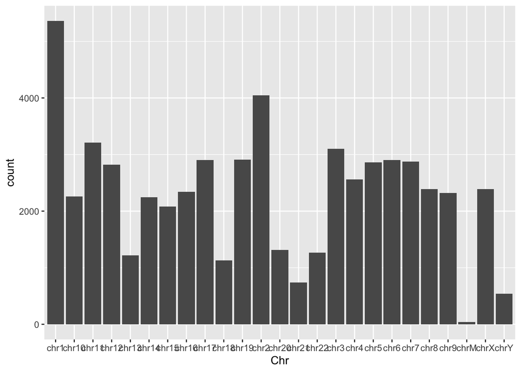

```r
gene_loc %>%                              # data
  ggplot(aes(x = Chr)) +                  # aesthetics: what to plot?
  geom_bar()                              # geometry: how to plot?
```

This looks messy. The names are overlapping, and the order is not correct. Let’s try making some adjustments.

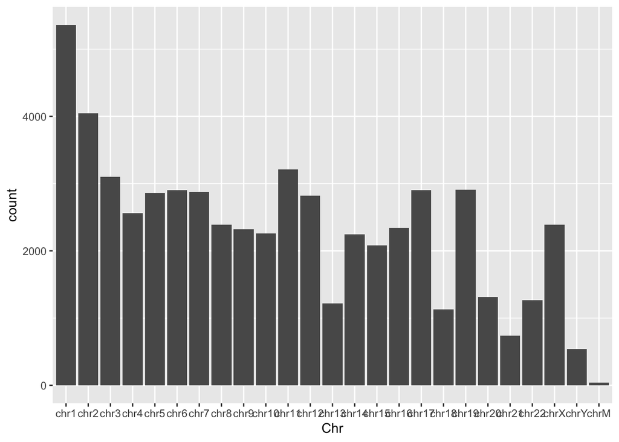

```r
# convert the chromosome names to factors
gene_loc$Chr <- factor(gene_loc$Chr,
                       levels = paste("chr",
                                      c((1:22), "X", "Y", "M"),
                                      sep=""))

# remember that you can assign names to ggplot objects
plot_chr_numgenes <- gene_loc %>%
                        ggplot(aes(x = Chr)) +
                        geom_bar()
plot_chr_numgenes
```

Still hard to read, so let’s try rotating the axes.

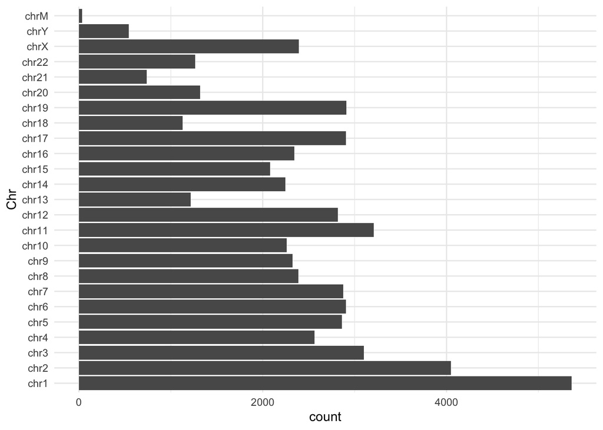

```r
plot_chr_numgenes +      # load the previously-named ggplot object
  coord_flip() +         # rotate the axes
  theme_minimal()        # change to a white background
```

Let’s say we want to the order to be reversed. We can also do that here.

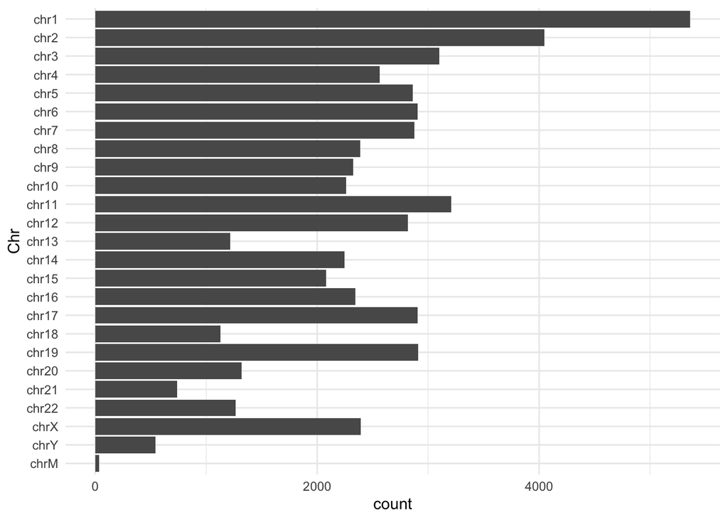

```r
plot_chr_numgenes +
  coord_flip() +
  theme_minimal() +
  scale_x_discrete(limits = rev(levels(gene_loc$Chr))) # change the order
```

Label the axes and assign a title

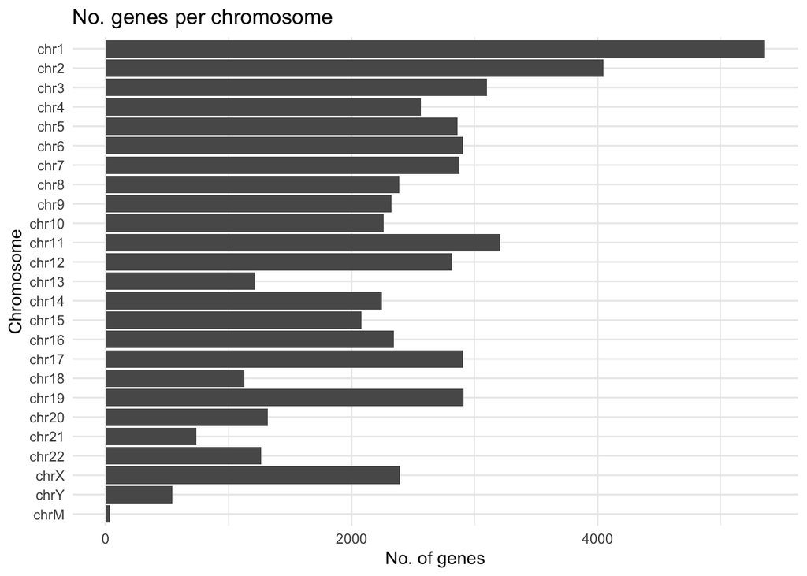

```r
plot_chr_numgenes +
  labs(title = "No. genes per chromosome",
       x = "Chromosome",
       y = "No. of genes") +
  theme_minimal() +
  coord_flip()+
  scale_x_discrete(limits = rev(levels(gene_loc$Chr)))
```

We can also make other geometries, such as a histogram.

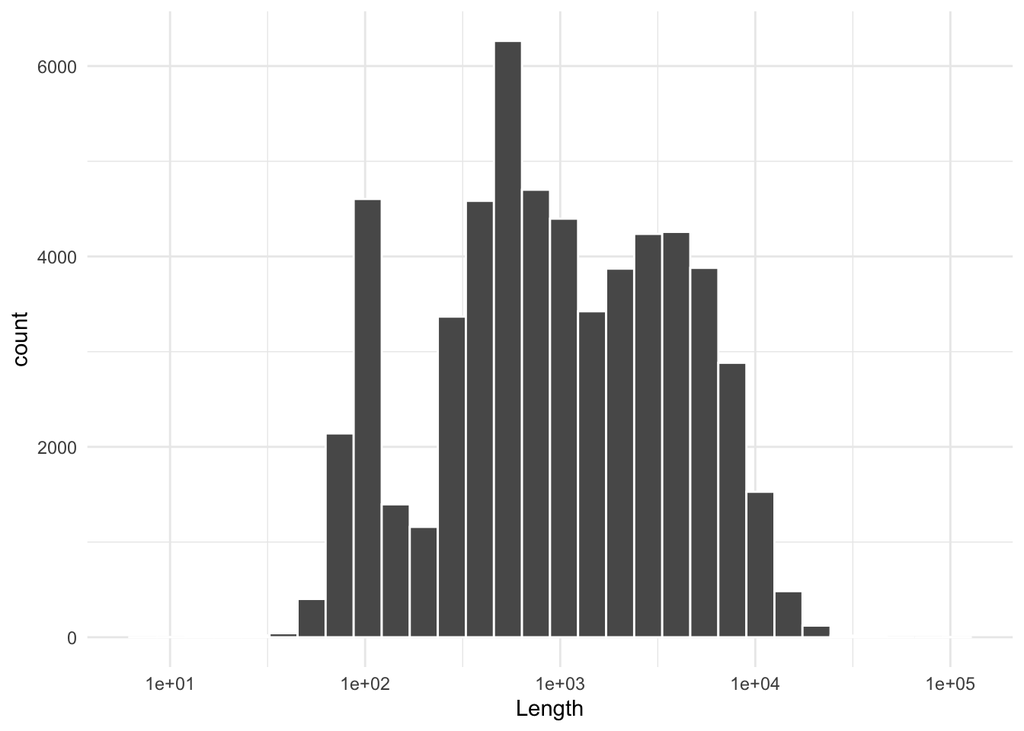

```r
gene_loc %>%
  ggplot(aes(x = Length)) +
  geom_histogram(color = "white") + # color here is the
  scale_x_log10() +                 # put the histogram on the log scale
  theme_minimal()
```

Next, we can separate the histograms into facets my chromosome name.

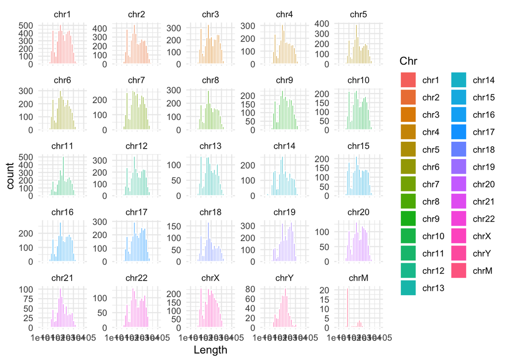

```r
# Create a facet grid using `facet_wrap()`.
plot_chr_genelength <- gene_loc %>%              # assign a new ggplot object
                          ggplot(aes(x = Length, fill = Chr)) +
                          geom_histogram(color = "white") +
                          scale_x_log10() +
                          theme_minimal() +
                          facet_wrap(~Chr, #sort facet by these data levels
                                     scales = "free_y") #only y-axis can vary
# view plot
plot_chr_genelength
```

Because each facet grid is already labeled, we do not need to have a legend. We also can rotate the axes using `theme()` and `element_text()`.

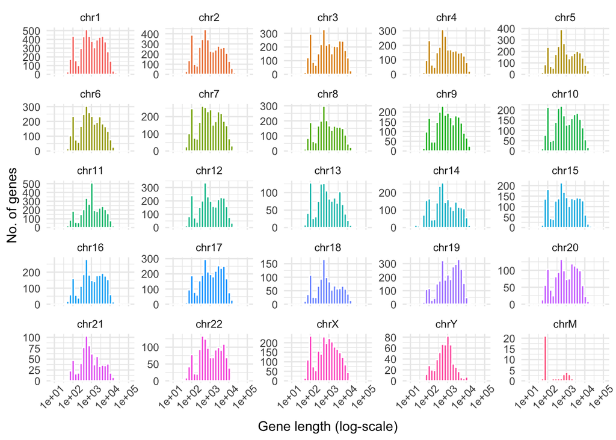

```r
# remove legend and add labels
plot_chr_genelength +
  theme(legend.position = "none") +
  labs(x = "Gene length (log-scale)",
       y = "No. of genes") +
  theme(axis.text.x = element_text(angle = 45, hjust = .75))
```

## A little more about aesthetics: Colors!

### Global versus data-level color scales

Notice that colors can be changed *globally* (i.e. all one color), or at the *data* level (factors, values).

For example:

`fill` here is at the data level (each facet has its own color).

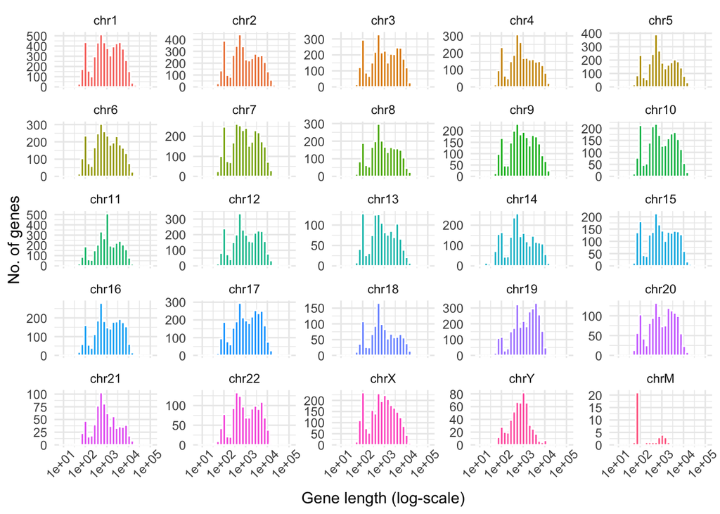

```r
gene_loc %>%
  ggplot(aes(x = Length, fill = Chr)) + # FILL is at the DATA level
  geom_histogram(color = "white") +
  scale_x_log10() +
  theme_minimal() +
  facet_wrap(~Chr, scales = "free_y") +
  theme(legend.position = "none") +
  labs(x = "Gene length (log-scale)",
       y = "No. of genes") +
  theme(axis.text.x = element_text(angle = 45, hjust = .75))
```

`fill` here is at the global level (all facets colored the same).

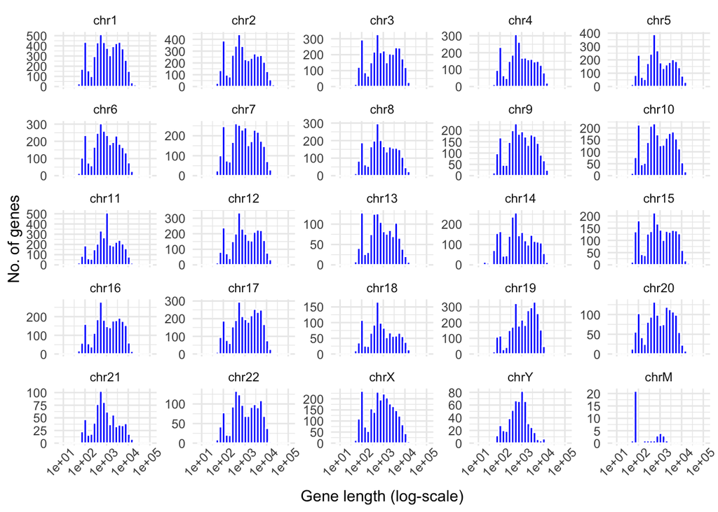

```r
gene_loc %>%
  ggplot(aes(x = Length)) + # FILL at the DATA level is REMOVED
  geom_histogram(color = "white", fill="blue") + # FILL is now GLOBAL
  scale_x_log10() +
  theme_minimal() +
  facet_wrap(~Chr, scales = "free_y") +
  theme(legend.position = "none") +
  labs(x = "Gene length (log-scale)",
       y = "No. of genes") +
  theme(axis.text.x = element_text(angle = 45, hjust = .75))
```

### Customized color scales

You can use `scales` to customize your colors. Or, you can use them to match the level or categorical feature you mention in `aes(fill=...)` or `aes(color=...)`. In this sense, scales “talk” to the aesthetics functions and work hand-in-hand.

Here are some to consider:

- scale_color_manual/scale_fill_manual (colorize by levels in the data)
- scale_color_discrete/scale_fill_discrete (categorical values)
- scale_color_gradientn/scale_fill_gradientn (gradient of n colors)
- scale_color_gradient/scale_fill_gradient (2-color gradient; low-high)
- scale_color_gradient/scale_fill_gradient (diverging 2-color gradient; low-mid-high)
- scale_color_colorblind/scale_fill_colorblind (up to 8 colorblind-friendly colors)
- scale_color_brewer/scale_fill_brewer (based on color brewer)
- scale_color_grey/scale_fill_grey (grey colors)

To use them, you need color palettes, such as these below:

**Color palettes from http://colorbrewer2.org** (made by a geography student at MSU!)

```r
# load colorbrewer library
library(RColorBrewer)
```

Check out the colors that they offer.

```r
# show all colors
  display.brewer.all()
```

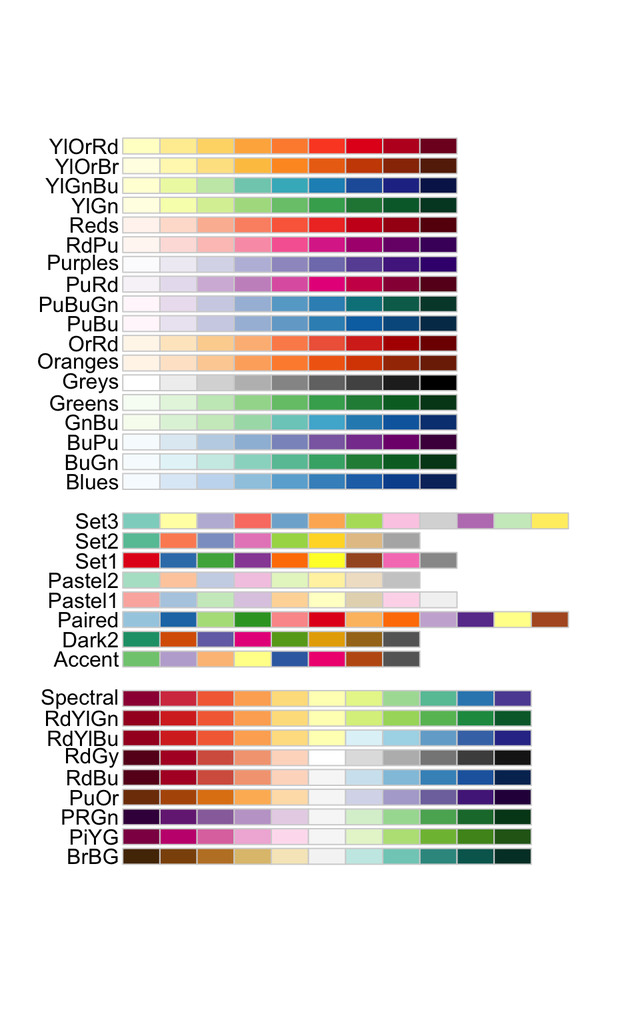

You can change the number according to how many colors you’d like to use to see what’s available.

```r
# show side-by-side
  par(mfrow=c(1,2))

# show 3 colors
  display.brewer.all(3)

# show for 10 colors
  display.brewer.all(10)
```

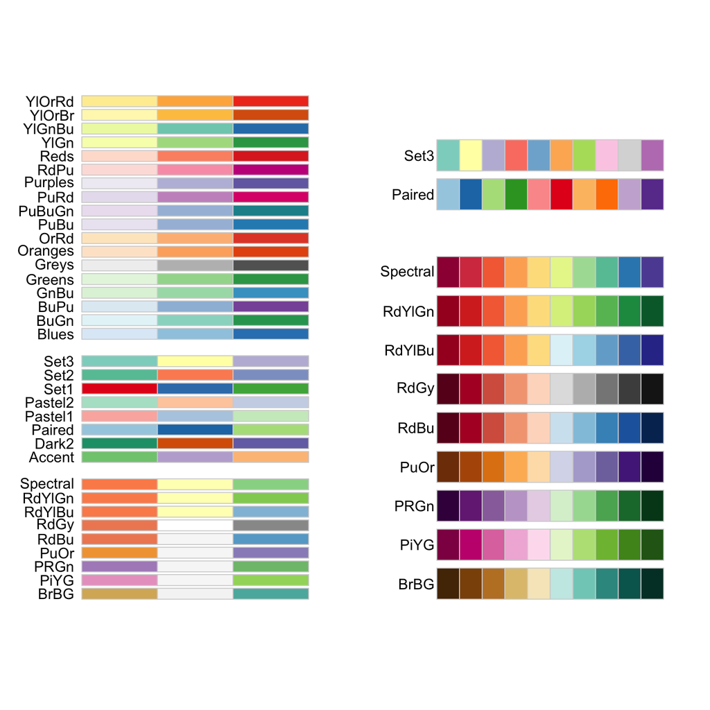

Quick example using `scale_fill_manual()`:

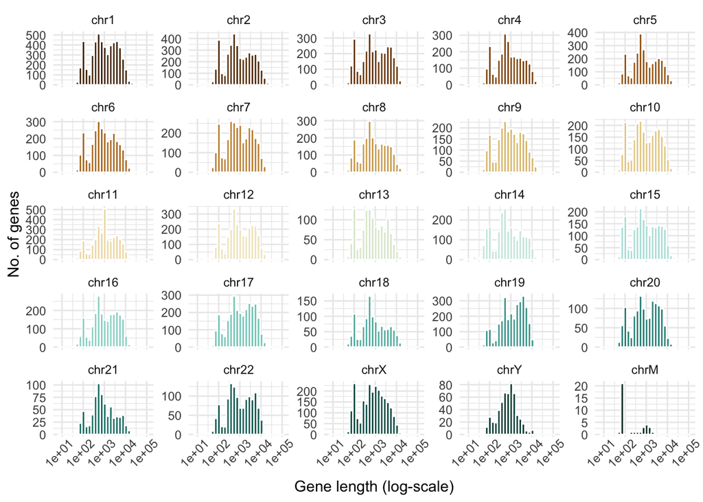

```r
# Because we have more data levels than the colorbrewer colors, make a palette
num_cols <- length(levels(gene_loc$Chr)) #get number of colors needed
newcolors <- colorRampPalette(brewer.pal(10, "BrBG"))(num_cols) #select palette

# make a new ggplot object with the basics (going to use later)
num_genes_chr <- gene_loc %>%
        ggplot(aes(x = Length, fill = Chr)) + # FILL is at the DATA level
        geom_histogram(color = "white") +
        scale_x_log10() +
        theme_minimal() +
        facet_wrap(~Chr, scales = "free_y") +
        theme(legend.position = "none") +
        labs(x = "Gene length (log-scale)",
             y = "No. of genes") +
        theme(axis.text.x = element_text(angle = 45, hjust = .75))

# add custom colors
num_genes_chr +
  scale_fill_manual(values = newcolors) # try values=rev(newcolors) too!
```

**Wes Anderson palettes, from the tumbler blog, https://wesandersonpalettes.tumblr.com/.**

```r
# load library
  library(wesanderson)
```

```r
# get names of movie color themes
  names(wes_palettes)
```

```
##  [1] "BottleRocket1"  "BottleRocket2"  "Rushmore1"      "Rushmore"
##  [5] "Royal1"         "Royal2"         "Zissou1"        "Darjeeling1"
##  [9] "Darjeeling2"    "Chevalier1"     "FantasticFox1"  "Moonrise1"
## [13] "Moonrise2"      "Moonrise3"      "Cavalcanti1"    "GrandBudapest1"
## [17] "GrandBudapest2" "IsleofDogs1"    "IsleofDogs2"
```

```r
# show side-by-side
  par(mfrow=c(3,3))

# print out a few to see what they look like
  wes_palette("FantasticFox1")    #Fantastic Mr. Fox (2009)
  wes_palette("Zissou1")          #The Life Aquatic with Steve Zissou (2004)
  wes_palette("GrandBudapest1")   #The Grand Budapest Hotel (2014)
  wes_palette("GrandBudapest2")   #The Grand Budapest Hotel (2014)
  wes_palette("Darjeeling1")      #The Darjeeling Limited (2007)
  wes_palette("Darjeeling2")      #The Darjeeling Limited (2007)
  wes_palette("Royal1")           #The Royal Tenenbaums (2001)
  wes_palette("Royal2")           #The Royal Tenenbaums (2001)
  wes_palette("Moonrise1")        #Moonrise Kingdom (2012)
```

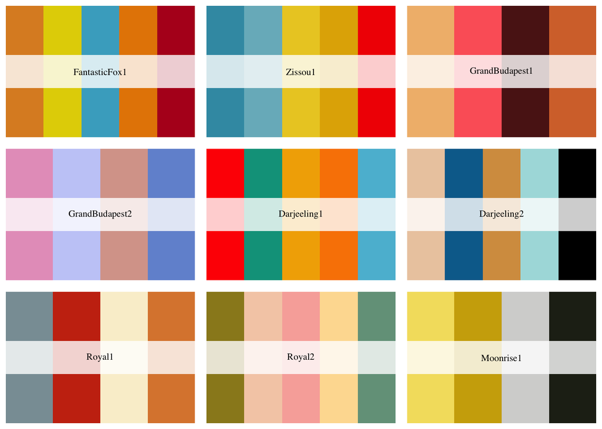

Quick example using one of these:

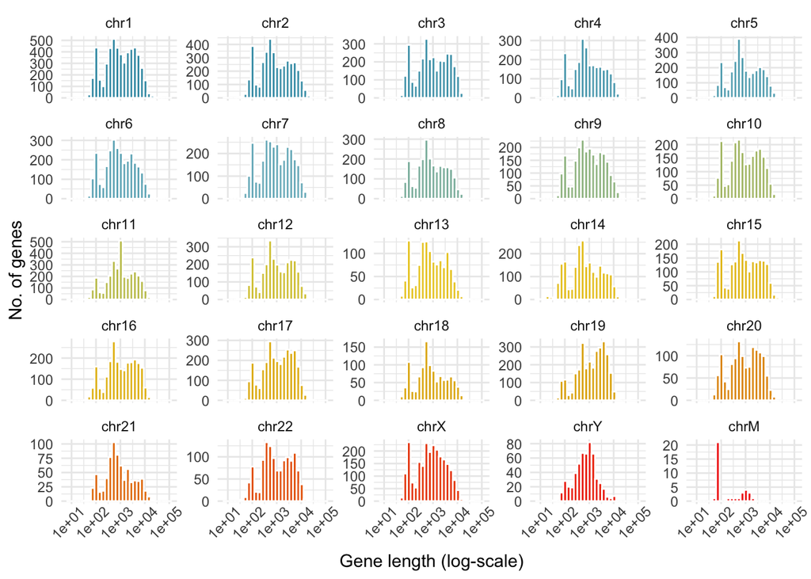

```r
newcolors <- wes_palette(name = "Zissou1", #select one of the color names
                         n = num_cols,
                         type = "continuous") #as opposed to "discrete"

# add custom colors
num_genes_chr +
  scale_fill_manual(values = newcolors)
```

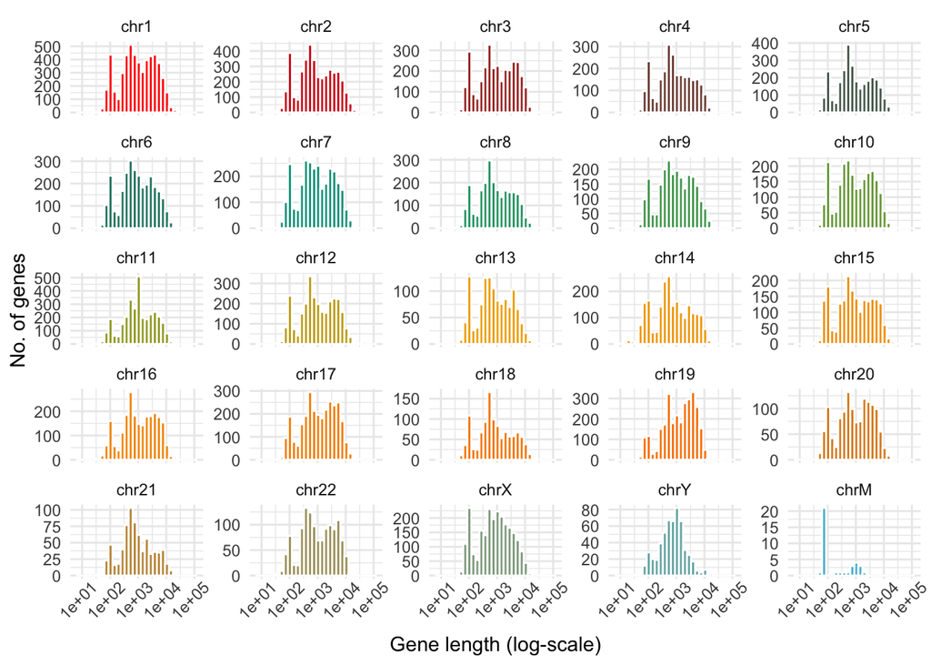

```r
# another way to do it is within scale_fill_manual
num_genes_chr +
  scale_fill_manual(values = wes_palette(n=num_cols, name = 'Darjeeling1', type = "continuous"))
```

**Other color sources to check out**

Color-blind-friendly colors from Paul Tol: https://personal.sron.nl/~pault/data/colourschemes.pdf

R color cheatsheet: https://www.nceas.ucsb.edu/~frazier/RSpatialGuides/colorPaletteCheatsheet.pdf

Viridis color library:

```r
#install.packages("viridis")
#library(viridis)
```